# How to work with Python

Christophe Pallier

Sept. 2017

You can use Python in several ways: interactively with `jupyter notebook` or with an `ipython` command line, or using an edit-run cycle approach with a program editor (e.g. `atom`, `idle`, `spyder`,…).

First of all, you need to be able to open a command line window (a.k.a. **terminal**):

- Ubuntu-Linux: `Ctrl-Alt-T` (see https://help.ubuntu.com/community/UsingTheTerminal)
- MacOSX: Open `Finder/Applications/Utilities/Terminal` (see http://www.wikihow.com/Get-to-the-Command-Line-on-a-Mac)
- Windows: Launch `Anaconda prompt`

## Using jupyter notebook

Launch Jupyter Notebook from the Start Menu/Anaconda3 (in Windows) or type `jupyter notebook` in a terminal (Linux, MacOS):

A browser will open a page like the following:

[figure not shown]

Jupyter homepage

By cliking on `New` and selecting `Python [root]`, a new tab will show a page like below, where you can enter python code in ‘cells’. To execute the code in a cell, just move the cursor there and press `Ctrl+Enter`

[figure not shown]

Jupyter notebook

A nice feature of the Jupyter notebooks is persistence, i.e. they are saved automatically (in `.ipynb` files) and you can go on working on the same notebook whn you reopen it. This is also very handy, for example, to send a data analysis report by email.

Jupyter’s documentation is available at http://jupyter.readthedocs.io/en/latest/index.html

## Using ipython

1. Open Anaconda Prompt (Windows) or a terminal (Linux, MacOS).
2. Type `ipython` on the command-line and press `Enter`:

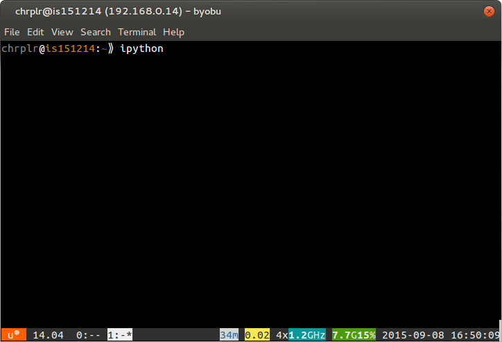

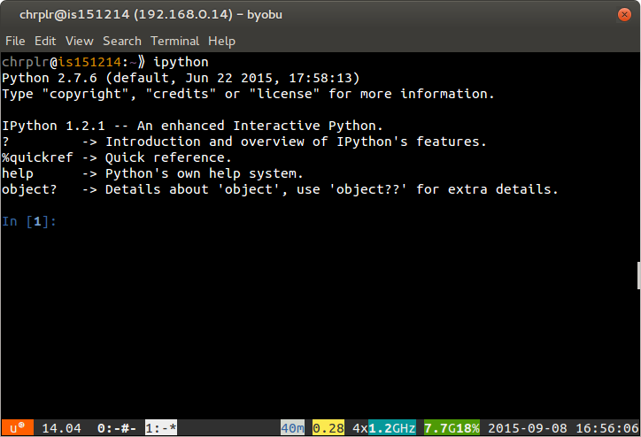

3. When your terminal looks like the one of the right, you are “talking” to ipython. Enter the following commands:

```python
    import turtle
    turtle.circle(50)
    turtle;forward(100)
    turtle.circle(50)

    turtle.right(90)
    turtle.forward(100)
    turtle.right(90)
    turtle.heading()
```

This way of using Python is fine if you need to quickly test an idea. But as soon as you quit `ipython` (by pressing `Ctrl-D`), you lose all traces of what you have done. To avoid that, you want to use the **Edit-run* approach.

## Using a text editor (Edit-run cycle)

Using a **text editor**, e.g. *atom*, you write a python script, that is, a series of commands, that you save in a file; then you give this file to interpret to a python interpreter. Here is how:

1. Open a Text-Editor (e.g. Atom) and a Terminal window side-by-side:

[figure not shown]

Using Atom and a Terminal side by side

2. Create a `New File` in the Editor and enter the following text:

```python
    import turtle
    turtle.forward(50)
    turtle.left(120)
    turtle.forward(100)
    turtle.left(120)
    turtle.forward(100)
    turtle.left(120)
    turtle.forward(50)
```

3. Using ‘File/Save as’, save the this text under the filename `myscript.py` in your personal (home) directory
- *run* with a python interpreter, by typing `python myscript.py` on a command line of the Terminal. Try it now.

Important: you must make sure that the *current working directory* of the terminal is the same directory where the file `myscript.py` has been saved. Otherwise, you will get an error message such as ‘No such file or directory’. To fix this problem, you must use the `cd` command to navigate the directory structure.

Remarks:

- You can learn more about Turtle graphics by reading the documentation at https://docs.python.org/2/library/turtle.html

## Using an Integrated Development Environment

Some people like to work within a single application and avoid going back and forth from the text editor to the terminal. A nice application for Python developement is `spyder`, which provides an environment somewhat similar to the MATLAB IDE.

[figure not shown]

The “spyder” Integrated Development Environment